# Applying Association Rule, Market Basket Analysis on everyday product to understand the association of products with each other and Recommedation.

What is Market Basket Analysis

Market basket analysis scrutinizes the products customers tend to buy together, and uses the information to decide which products should be cross-sold or promoted together. The term arises from the shopping carts supermarket shoppers fill up during a shopping trip. Source: https://www.springer.com/gp/book/9780387725789

Market Baket Analysis is usually performed on transaction data from a customer's sale point of view.

Market Basket Analysis can be used to extract interesting product associations from data.

As a consequence, its production is a set of product association rules: for example, consumers who buy product A are more likely to buy product B.

Today, We will learn how product A is dependent on Product B and we can recommend the shop owner to promote both the product together to increase the overall sales and hence the total profit.

We depend on historical transaction to understand or predict future transaction.

-Loading necessary libraries

mlxtend.frequent_pattern is important to install as it is used in apriori, association rules, fpgrowth and fpmax.

- pip install mlxtend

The purpose of mlxtend.frequent_pattern is to import below apriori: Get frequent itemsets from a one-hot DataFrame apriori(df, min_support=0.5, use_colnames=False, max_len=None, verbose=0, low_memory=False)

association_rules: Generates a DataFrame of association rules including the metrics 'score', 'confidence', and 'lift' association_rules(df, metric='confidence', min_threshold=0.8, support_only=False)

```python
import pandas as pd
import numpy as np
import seaborn as sns
import matplotlib.pyplot as plt
from mlxtend.frequent_patterns import apriori
from mlxtend.frequent_patterns import association_rules
import mlxtend as ml
```

Data Source: https://www.kaggle.com/mittalvasu95/the-bread-basket

The dataset has transactions of customers who ordered different items from this bakery online.

```python
bread = pd.read_csv(r"C:\\Users\\Karan\\Desktop\\kaggle\\breadbasket.csv")
bread.head(8) #To view the dataset
```

|  | Transaction | Item | date_time | period_day | weekday_weekend |
| --- | --- | --- | --- | --- | --- |
| 0 | 1 | Bread | 30-10-2016 09:58 | morning | weekend |
| 1 | 2 | Scandinavian | 30-10-2016 10:05 | morning | weekend |
| 2 | 2 | Scandinavian | 30-10-2016 10:05 | morning | weekend |
| 3 | 3 | Hot chocolate | 30-10-2016 10:07 | morning | weekend |
| 4 | 3 | Jam | 30-10-2016 10:07 | morning | weekend |
| 5 | 3 | Cookies | 30-10-2016 10:07 | morning | weekend |
| 6 | 4 | Muffin | 30-10-2016 10:08 | morning | weekend |
| 7 | 5 | Coffee | 30-10-2016 10:13 | morning | weekend |

The data contains 20507 Entries or rows and 5 Column which are 'Transaction', 'Item', 'date_time', 'period_day' and 'weekday_weekend'.

```python
bread.shape
```

```
(20507, 5)
```

We have used Value_Counts function to understand the most sold product in the bakery and we found that coffee is on the top with '5471' unit of sales and Bread comes on second number with '3325' units.

Now, we have some clarity about the data in terms of highest sold product in the bakery.

```python
bread['Item'].value_counts()
```

```
Coffee        5471
Bread         3325
Tea           1435
Cake          1025
Pastry         856
              ...
Adjustment       1
Polenta          1
The BART         1
Bacon            1
Raw bars         1
Name: Item, Length: 94, dtype: int64
```

```python
#Separating transactions from weekend and time of the day
mybasket = (bread[bread['weekday_weekend'] =="weekday"]
          .groupby(['Transaction', 'period_day'])['Item']
          .sum().unstack().reset_index().fillna(0)
          .set_index('Transaction'))
```

```python
#viewing transaction basket
mybasket.head()
```

| period_day Transaction | afternoon | evening | morning | night |
| --- | --- | --- | --- | --- |
| 81 | 0 | 0 | CoffeeCake | 0 |
| 82 | 0 | 0 | TartineBread | 0 |
| 83 | 0 | 0 | CoffeeBread | 0 |
| 84 | 0 | 0 | Bread | 0 |
| 85 | 0 | 0 | CoffeeCoffeePastryMedialuna | 0 |

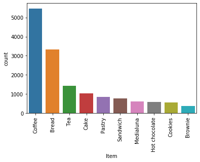

```python
sns.countplot(x = 'Item', data = bread, order = bread['Item'].value_counts().iloc[:10].index)
plt.xticks(rotation=90)
```

It seems like coffee are the hottest item in the dataset, I guess everybody wants a cup of hot coffee with bread in the morning perhaps.

```python
df = bread.groupby(['Transaction','Item']).size().reset_index(name='count')

basket = (df.groupby(['Transaction', 'Item'])['count']
          .sum().unstack().reset_index().fillna(0)
          .set_index('Transaction'))
```

```python
#The encoding function
def encode_units(x):
    if x <= 0:
        return 0
    if x >= 1:
        return 1

basket_sets = basket.applymap(encode_units)
```

The above encoding function will convert all the number which are less than or equal to zero to zero and number which are greater then or equal to one to one. Why are we doing this because we want in our data set to only contain value which is zero or one. This is what our algorithm of association rule expect the input to be in the form of zero or one.

Where Zero represents absense of and Item where One represent prensence of the item.

```python
frequent_itemsets = apriori(basket_sets, min_support=0.03, use_colnames=True) #Generatig frequent itemsets
```

```python
rules = association_rules(frequent_itemsets, metric="lift",min_threshold=1) #generating rules
```

```python
rules.sort_values('confidence', ascending = False, inplace = True) #generating rules
```

```python
rules.head(10) #viewing top 10 rules
```

|  | antecedents | consequents | antecedent support | consequent support | support | confidence | lift | leverage | conviction |
| --- | --- | --- | --- | --- | --- | --- | --- | --- | --- |
| 2 | (Medialuna) | (Coffee) | 0.061807 | 0.478394 | 0.035182 | 0.569231 | 1.189878 | 0.005614 | 1.210871 |
| 5 | (Pastry) | (Coffee) | 0.086107 | 0.478394 | 0.047544 | 0.552147 | 1.154168 | 0.006351 | 1.164682 |
| 6 | (Sandwich) | (Coffee) | 0.071844 | 0.478394 | 0.038246 | 0.532353 | 1.112792 | 0.003877 | 1.115384 |
| 1 | (Cake) | (Coffee) | 0.103856 | 0.478394 | 0.054728 | 0.526958 | 1.101515 | 0.005044 | 1.102664 |
| 0 | (Coffee) | (Cake) | 0.478394 | 0.103856 | 0.054728 | 0.114399 | 1.101515 | 0.005044 | 1.011905 |
| 4 | (Coffee) | (Pastry) | 0.478394 | 0.086107 | 0.047544 | 0.099382 | 1.154168 | 0.006351 | 1.014740 |
| 7 | (Coffee) | (Sandwich) | 0.478394 | 0.071844 | 0.038246 | 0.079947 | 1.112792 | 0.003877 | 1.008807 |
| 3 | (Coffee) | (Medialuna) | 0.478394 | 0.061807 | 0.035182 | 0.073542 | 1.189878 | 0.005614 | 1.012667 |

Conclusion

Lift: It measures how many times more often X and Y occur togehter than expected if they are statistically independent of each other. lift is a measure of how X and Y are really related than coincidentally happening together. For Example:If Lift value greater than 1 then item x is more likely to be brought with Y, Here coffee is more likely to be bought with Medialuna as is lift is greater than one which is '1.18'.

Making Recomendation:

From the output, the lift of the association rule "If Medialuna then coffee" is 1.18 because the confidence is 56%. This means that consumer who purchase Medialuna are 1.18 times more likely to buy coffee than a random customer.

References:

While choosing the above topic and data set for this, I have tried the same on 3 different dataset and I found that the breadbasket dataset provide a better picture. For which I have choosed it.

I have also learned deeply every aspect of association rule and apriori algorithm in Market Basket Analysis.

https://www.youtube.com/watch?v=4QIWJVVWJdQ

https://towardsdatascience.com/mba-for-breakfast-4c18164ef82b

https://www.kaggle.com/ekrembayar/apriori-association-rules-grocery-store